# Week 4 Lecture

### What is pandas?

pandas is a Python library used for data manipulation and analysis that buil on top of the Python programming language.

Pandas work well with CSV file (e.g., excel, SQL)

### Key features of Python Pandas

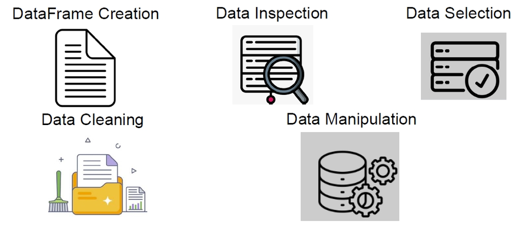

### Import Pandas in Python

It is recommended to install and run pandas from a virtual environment

#### Create a virtual environment

Right click the Anaconda prompt and **Run as Administrator** (This step will ensure that your package is installed in *Anaconda/env* folder)

```
conda create -n pda python=3.9
```

#### List virtual environment

now if you list virgual envionment, you can see the virtual environment that you just create

```
conda env list
```

#### Activate virtual environment

```
activate pda
```

#### Install pandas

```
conda install pandas
```

### Download data in CSV format

[Data Source: The city of Worcester](https://opendata.worcesterma.gov/search?collection=dataset&sort=Date%20Updated%7Cmodified%7Cdesc)

Search: Worcester Police Use of Force Incidents (July 2024)

Download CSV

### Loading a Pandas DataFrame from CSV file

```python
import pandas as pd
```

import pandas as pd

```python
## use the dir() function to list all the attributes (include functions) in python
print(dir(pd))
```

## use the dir() function to list all the attributes (include functions) in python print(dir(pd))

```
['ArrowDtype', 'BooleanDtype', 'Categorical', 'CategoricalDtype', 'CategoricalIndex', 'DataFrame', 'DateOffset', 'DatetimeIndex', 'DatetimeTZDtype', 'ExcelFile', 'ExcelWriter', 'Flags', 'Float32Dtype', 'Float64Dtype', 'Grouper', 'HDFStore', 'Index', 'IndexSlice', 'Int16Dtype', 'Int32Dtype', 'Int64Dt…
```

#### read csv

```python
incidents = pd.read_csv(r'D:\Teaching_Data\Worcester_Police_Use_of_Force_Incidents_July_2024.csv')
incidents.head(n=3)
```

incidents = pd.read_csv(r'D:\Teaching_Data\Worcester_Police_Use_of_Force_Incidents_July_2024.csv') incidents.head(n=3)

[output not shown]

#### A concise summary of a DataFrame

```python
incidents.info()
```

incidents.info()

```
<class 'pandas.core.frame.DataFrame'>
RangeIndex: 74 entries, 0 to 73
Data columns (total 10 columns):
 #   Column       Non-Null Count  Dtype
---  ------       --------------  -----
 0   Incident_No  74 non-null     int64
 1   Date___Time  74 non-null     object
 2   Location     74 non-null     object
 3   Officer      74 non-null     object
 4   Narr         74 non-null     int64
 5   Implement    74 non-null     object
 6   Injury       74 non-null     object
 7   Supervisor   74 non-null     object
 8   Notified     74 non-null     object
 9   ObjectId     74 non-null     int64
dtypes: int64(3), object(7)
memory usage: 5.9+ KB
```

```python
incidents.shape
```

incidents.shape

```
(74, 10)
```

#### Series and DataFrame

Series: A one-dimensional labeled array capable of holding data of any type (integers, strings, floating-point numbers, etc.).

DataFrame: A two-dimensional tabular data structure with labeled axes (rows and columns).

#### Access a column

```python
# Access a column as series
col_series = incidents['Narr']
print(col_series)
type(col_series)
```

# Access a column as series col_series = incidents['Narr'] print(col_series) type(col_series)

```
0     1
1     3
2     2
3     3
4     6
     ..
69    5
70    2
71    1
72    4
73    2
Name: Narr, Length: 74, dtype: int64
```

```
pandas.core.series.Series
```

```python
# Access a column as Series (2nd syntax)
col_series02 = incidents.Narr
print(type(col_series02))
col_series02
```

# Access a column as Series (2nd syntax) col_series02 = incidents.Narr print(type(col_series02)) col_series02

```
<class 'pandas.core.series.Series'>
```

```
0     1
1     3
2     2
3     3
4     6
     ..
69    5
70    2
71    1
72    4
73    2
Name: Narr, Length: 74, dtype: int64
```

```python
## Access a column as DataFrame
col_df = incidents[['Narr']]
print(col_df)
type(col_df)
```

## Access a column as DataFrame col_df = incidents[['Narr']] print(col_df) type(col_df)

```
    Narr
0      1
1      3
2      2
3      3
4      6
..   ...
69     5
70     2
71     1
72     4
73     2

[74 rows x 1 columns]
```

```
pandas.core.frame.DataFrame
```

#### Access a row

The iloc() function is an indexed-based selecting method which means that we have to pass an integer index in the method to select a specific row/column.

```python
# Access a row as Series
row_series = incidents.iloc[0,:]
print(row_series)
type(row_series)
```

# Access a row as Series row_series = incidents.iloc[0,:] print(row_series) type(row_series)

```
Incident_No                                    2024000078279
Date___Time                                  7/29/24 1:09 PM
Location                         9 LINCOLN SQ Worcester, MA
Officer                                        Daniel Adjei
Narr                                                       1
Implement      R. Empty Hand Compliance Techniques / Level 3
Injury                                        Visible Injury
Supervisor                                  Neil F O'Connor
Notified                                     7/29/24 4:27 PM
ObjectId                                                   1
Name: 0, dtype: object
```

```
pandas.core.series.Series
```

```python
# Access a row as DataFrame
row_df = incidents.iloc[[0],:]
print(type(row_df))
row_df
```

# Access a row as DataFrame row_df = incidents.iloc[[0],:] print(type(row_df)) row_df

```
<class 'pandas.core.frame.DataFrame'>
```

|  | Incident_No | Date___Time | Location | Officer | Narr | Implement | Injury | Supervisor | Notified | ObjectId |
| --- | --- | --- | --- | --- | --- | --- | --- | --- | --- | --- |
| 0 | 2024000078279 | 7/29/24 1:09 PM | 9 LINCOLN SQ Worcester, MA | Daniel Adjei | 1 | R. Empty Hand Compliance Techniques / Level 3 | Visible Injury | Neil F O'Connor | 7/29/24 4:27 PM | 1 |

### Access multiple rows and columns

```python
##### Access multiple row using iloc()
sub_inci = incidents.iloc[0:5,0:3]
print(type(sub_inci))
sub_inci
```

##### Access multiple row using iloc() sub_inci = incidents.iloc[0:5,0:3] print(type(sub_inci)) sub_inci

```
<class 'pandas.core.frame.DataFrame'>
```

|  | Incident_No | Date___Time | Location |
| --- | --- | --- | --- |
| 0 | 2024000078279 | 7/29/24 1:09 PM | 9 LINCOLN SQ Worcester, MA |
| 1 | 2024000078796 | 7/30/24 4:38 PM | 6 SHANNON ST Apt #: 2 Worcester, MA |
| 2 | 2024000078796 | 7/30/24 4:38 PM | 6 SHANNON ST Apt #: 2 Worcester, MA |
| 3 | 2024000078953 | 7/30/24 9:50 PM | 79 MAYFIELD ST Worcester, MA |
| 4 | 2024000079115 | 7/31/24 11:05 AM | 70 JACKSON ST Worcester, MA |

#### Access columns or rows using loc()

The loc() function is label based data selecting method which means that we have to pass the name of the row or column which we want to select.

```python
rst = incidents.loc[0:1,['Incident_No', 'Date___Time', 'Location']]
rst
```

rst = incidents.loc[0:1,['Incident_No', 'Date___Time', 'Location']] rst

|  | Incident_No | Date___Time | Location |
| --- | --- | --- | --- |
| 0 | 2024000078279 | 7/29/24 1:09 PM | 9 LINCOLN SQ Worcester, MA |
| 1 | 2024000078796 | 7/30/24 4:38 PM | 6 SHANNON ST Apt #: 2 Worcester, MA |

### Exercise 1: Get record as series and Datafram from incidents

1. Get the record as series: 'Location' column
2. Get the record as DataFrame using index based method (.iloc): row 1 - 5 and column 2 - 3
3. Get the record as DataFrame using label based method (.loc): row 1-5 and column ['Supervisor', 'Notified']

### Data cleaning

#### Rename the column name

Check the columns names based on `incidents.columns`

```python
#format of columns can be the dictionary: old column name: new column name
print('column name are {} '.format(incidents.columns))

incidents.rename(columns={'Date___Time':'DateTime', 'Incident_No':"IncidentNo"}, inplace=True)

print('updated column name are {} '.format(incidents.columns))
```

#format of columns can be the dictionary: old column name: new column name print('column name are {} '.format(incidents.columns)) incidents.rename(columns={'Date___Time':'DateTime', 'Incident_No':"IncidentNo"}, inplace=True) print('updated column name are {} '.format(incidents.columns))

[output not shown]

#### Check Null value

[pandas.DataFrame.isnull](https://pandas.pydata.org/docs/reference/api/pandas.DataFrame.isnull.html) check missing value

[pandas.DataFrame.sum](https://pandas.pydata.org/docs/reference/api/pandas.DataFrame.sum.html) the sum of the values over the requested axis.

```python
# check null value in each cell
incidents.isnull().head(n = 5)
```

# check null value in each cell incidents.isnull().head(n = 5)

|  | IncidentNo | DateTime | Location | Officer | Narr | Implement | Injury | Supervisor | Notified | ObjectId |
| --- | --- | --- | --- | --- | --- | --- | --- | --- | --- | --- |
| 0 | False | False | False | False | False | False | False | False | False | False |
| 1 | False | False | False | False | False | False | False | False | False | False |
| 2 | False | False | False | False | False | False | False | False | False | False |
| 3 | False | False | False | False | False | False | False | False | False | False |
| 4 | False | False | False | False | False | False | False | False | False | False |

```python
# calcualte the sum for each column
incidents.isnull().sum()
```

# calcualte the sum for each column incidents.isnull().sum()

```
IncidentNo    0
DateTime      0
Location      0
Officer       0
Narr          0
Implement     0
Injury        0
Supervisor    0
Notified      0
ObjectId      0
dtype: int64
```

#### Get unique value of the columns

unique() function in pandas

[pandas.unique](https://pandas.pydata.org/docs/reference/api/pandas.unique.html)

```python
multi_col = incidents.loc[:,['Injury', 'Narr']]
pd.unique(multi_col)
```

multi_col = incidents.loc[:,['Injury', 'Narr']] pd.unique(multi_col)

[output not shown]

```python
unique_col = {}
for col in multi_col.columns:
    unique_col[col] = pd.unique(multi_col[col])
unique_col
```

unique_col = {} for col in multi_col.columns: unique_col[col] = pd.unique(multi_col[col]) unique_col

```
{'Injury': array(['Visible Injury', '_None', 'Complaint of Injury'], dtype=object),
 'Narr': array([ 1,  3,  2,  6,  4, 12,  7,  5,  8,  9, 10], dtype=int64)}
```

### DataFrame Manipulation

#### Data sorting

pandas.DataFrame.sort_values

pandas.Series.sort_values

```python
inct_sort_narr = incidents.sort_values(by="Narr", ascending=False)
inct_sort_narr.head(n = 6)
```

inct_sort_narr = incidents.sort_values(by="Narr", ascending=False) inct_sort_narr.head(n = 6)

[output not shown]

### Exercise 2: sort values based on Officer (String)

sort_values() function sort the number from smallest to largest (ascending) descending

how about sort the String?

#### Data query: single condition

```python
unique_injury = incidents.loc[:,"Injury"].unique()
print('unique value: {}'.format(unique_injury))
```

unique_injury = incidents.loc[:,"Injury"].unique() print('unique value: {}'.format(unique_injury))

```
unique value: ['Visible Injury' '_None' 'Complaint of Injury']
```

```python
none_incident = incidents.query('Injury == "_None"')
print(none_incident.shape)
```

none_incident = incidents.query('Injury == "_None"') print(none_incident.shape)

```
(68, 10)
```

### Exercise 3: How many incidents' injury type are 'Visible Injury'

#### Data query: multiple condition

Query how many incidents's Narr are larger than 6 and Implement are 'I. Display of Firearm'

```python
none_firearm = incidents.query('Narr > 6 & Implement == "I. Display of Firearm"')
none_firearm.shape
```

none_firearm = incidents.query('Narr > 6 & Implement == "I. Display of Firearm"') none_firearm.shape

```
(4, 10)
```

### DateTime

Pandas provides the `pd.to_datetime()` function to convert string data into a datetime object:

```python
incidents['DateTime']
```

incidents['DateTime']

```
0      7/29/24 1:09 PM
1      7/30/24 4:38 PM
2      7/30/24 4:38 PM
3      7/30/24 9:50 PM
4     7/31/24 11:05 AM
            ...
69    7/27/24 12:43 AM
70    7/29/24 11:41 AM
71    7/29/24 11:41 AM
72     7/29/24 1:09 PM
73     7/29/24 1:09 PM
Name: DateTime, Length: 74, dtype: object
```

```python
# create a new column to store the DateTime
incidents['DT'] = pd.to_datetime(incidents['DateTime'], format = "%m/%d/%y %I:%M %p")
```

# create a new column to store the DateTime incidents['DT'] = pd.to_datetime(incidents['DateTime'], format = "%m/%d/%y %I:%M %p")

```python
# sort value based on 'DateTime' or 'DT' to see the difference
incidents.sort_values(by='DT', ascending=True).head(n=5)
```

# sort value based on 'DateTime' or 'DT' to see the difference incidents.sort_values(by='DT', ascending=True).head(n=5)

|  | IncidentNo | DateTime | Location | Officer | Narr | Implement | Injury | Supervisor | Notified | ObjectId | DT |
| --- | --- | --- | --- | --- | --- | --- | --- | --- | --- | --- | --- |
| 7 | 2024000065816 | 7/1/24 9:46 AM | 25 QUEEN ST Worcester, MA | Joseph L Ford | 1 | R. Empty Hand Compliance Techniques / Level 3 | _None | Justin Bennes | 7/1/24 4:00 PM | 8 | 2024-07-01 09:46:00 |
| 9 | 2024000066207 | 7/2/24 10:11 AM | 275 PLEASANT ST Apt #: 713 Worcester, MA | John Biancaniello | 1 | G. Display of Taser or Sparks Display | _None | MIGUEL DIAZ | 7/2/24 11:45 AM | 10 | 2024-07-02 10:11:00 |
| 8 | 2024000066207 | 7/2/24 10:11 AM | 275 PLEASANT ST Apt #: 713 Worcester, MA | David C McAtee | 2 | I. Display of Firearm | _None | MIGUEL DIAZ | 7/2/24 12:11 PM | 9 | 2024-07-02 10:11:00 |
| 10 | 2024000066256 | 7/2/24 12:02 PM | 25 TOBIAS BOLAND WAY Worcester, MA | James P Ciru | 1 | R. Empty Hand Compliance Techniques / Level 3 | _None | Jeffrey P Carlson | 7/2/24 1:04 PM | 11 | 2024-07-02 12:02:00 |
| 11 | 2024000066380 | 7/2/24 5:16 PM | 810 MAIN ST Worcester, MA | Stephen J Mitchell | 2 | R. Empty Hand Compliance Techniques / Level 3 | _None | Christopher A Panarello | 7/2/24 5:11 PM | 12 | 2024-07-02 17:16:00 |

```python
incidents.info()
```

incidents.info()

```
<class 'pandas.core.frame.DataFrame'>
RangeIndex: 74 entries, 0 to 73
Data columns (total 11 columns):
 #   Column      Non-Null Count  Dtype
---  ------      --------------  -----
 0   IncidentNo  74 non-null     int64
 1   DateTime    74 non-null     object
 2   Location    74 non-null     object
 3   Officer     74 non-null     object
 4   Narr        74 non-null     int64
 5   Implement   74 non-null     object
 6   Injury      74 non-null     object
 7   Supervisor  74 non-null     object
 8   Notified    74 non-null     object
 9   ObjectId    74 non-null     int64
 10  DT          74 non-null     datetime64[ns]
dtypes: datetime64[ns](1), int64(3), object(7)
memory usage: 6.5+ KB
```

### Get weekday from the DateTime

[pandas.Series.dt](https://pandas.pydata.org/docs/reference/api/pandas.Series.dt.html)

```python
incidents['wday'] = incidents.DT.dt.weekday
```

incidents['wday'] = incidents.DT.dt.weekday

```python
incidents['wday'].unique()
```

incidents['wday'].unique()

```
array([0, 1, 2, 3, 4, 5, 6])
```

### Exercise 4: Get year and hour from the DateTime and assign to a new column

incidents['yr']

incidents[hr]

```python
incidents['yr'] = incidents.DT.dt.year
incidents['hr'] = incidents.DT.dt.hour
```

incidents['yr'] = incidents.DT.dt.year incidents['hr'] = incidents.DT.dt.hour

### Aggregating statistics

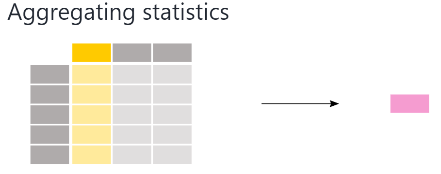

#### Aggregating Statistics of a single column

[pandas.DataFrame.mean](https://pandas.pydata.org/pandas-docs/stable/reference/api/pandas.DataFrame.mean.html)

```python
incidents['Narr'].mean()
```

incidents['Narr'].mean()

```
2.9324324324324325
```

```python
incidents[["Narr"]].describe()
```

incidents[["Narr"]].describe()

|  | Narr |
| --- | --- |
| count | 74.000000 |
| mean | 2.932432 |
| std | 2.377584 |
| min | 1.000000 |
| 25% | 1.000000 |
| 50% | 2.000000 |
| 75% | 3.000000 |
| max | 12.000000 |

#### Aggregating statistics grouped by category

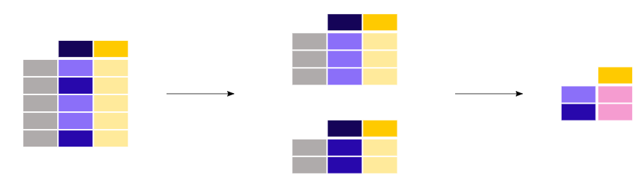

```python
incidents[["Narr", "wday"]].groupby("wday").mean()
```

incidents[["Narr", "wday"]].groupby("wday").mean()

| wday | Narr |
| --- | --- |
| 0 | 3.142857 |
| 1 | 2.700000 |
| 2 | 2.307692 |
| 3 | 2.111111 |
| 4 | 2.833333 |
| 5 | 4.200000 |
| 6 | 2.428571 |

### Exercise 5: Count the incidents based on day of week

using count() to count the incidents for each day of week

Group IncidentNo based on wday, then count the occurrence of incidentNo for each wday

Sort the wday based on the total number of incidents

```python
incidents[["IncidentNo", "wday"]].groupby("wday").count()
```

incidents[["IncidentNo", "wday"]].groupby("wday").count()

| wday | IncidentNo |
| --- | --- |
| 0 | 14 |
| 1 | 10 |
| 2 | 13 |
| 3 | 9 |
| 4 | 6 |
| 5 | 15 |
| 6 | 7 |

### Spatially Enabled Data Frame

The Spatially Enabled DataFrame (SEDF) creates a simple, intutive object that can easily manipulate attribute and geometric data.

Create SEDF from a Shapefile

An SEDF still includes access to all the Pandas DataFrame functionality

#### Shapefile

A shapefile is made up of multiple files and all files must be found in the same folder with the same name

A shapefile must have the following:

- .shp – this file stores the geometry of the feature
- .shx – this file stores the index of the geometry
- .dbf – this file stores the attribute information for the feature